# ggplot2 Graphics

### Base plot vs. ggplot

GrDevices: the R graphics engine, provides infrastructure for:

- “graphics”: base graphics
- “grid”: newer, includes lattice and ggplot2 (see later this afternoon)

Both work quite differently.

Base graphics pros:

- very flexible, you can make virtually any type of graph, exactly how you want
- good for very quick data visualization

Cons:

- **complex graphs are not straightforward, if the graph can be made with ggplot, this will require much less code**
- **ggplot arguably has more pleasing defaults**

### ggplot - when you forget...

[Cheatsheet](https://www.rstudio.com/wp-content/uploads/2015/03/ggplot2-cheatsheet.pdf)

[Package 'ggplot2'](https://cran.r-project.org/web/packages/ggplot2/ggplot2.pdf) [ggplot2.org](http://ggplot2.org/)

[Function overview](http://ggplot2.tidyverse.org/reference/)

Various tutorials or quick learning

- [Quick-R](https://www.statmethods.net/advgraphs/ggplot2.html)
- [Harvard tutorial](http://tutorials.iq.harvard.edu/R/Rgraphics/Rgraphics.html)
- [Top 50 visualizations](http://r-statistics.co/Top50-Ggplot2-Visualizations-MasterList-R-Code.html)
- etc… Google is your friend

Books

- Wickham (2009) ggplot2: Elegent Graphics for Data Analysis
- Chang (2010) R Graphics Cookbook: Practival Recipes for Visualizing Data

### Some examples using ggplot2()

ggplot-package

```r
library(ggplot2)
```

dataset

```r
head(iris)
```

```
  Sepal.Length Sepal.Width Petal.Length Petal.Width Species
1          5.1         3.5          1.4         0.2  setosa
2          4.9         3.0          1.4         0.2  setosa
3          4.7         3.2          1.3         0.2  setosa
4          4.6         3.1          1.5         0.2  setosa
5          5.0         3.6          1.4         0.2  setosa
6          5.4         3.9          1.7         0.4  setosa
```

### Scatterplot

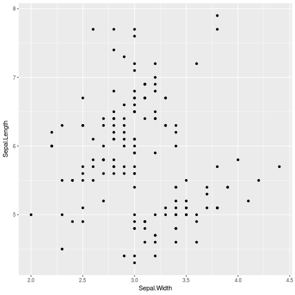

```r
ggplot(data=iris, aes(x = Sepal.Width, y= Sepal.Length)) +
  geom_point()
```

Compared with base plot:

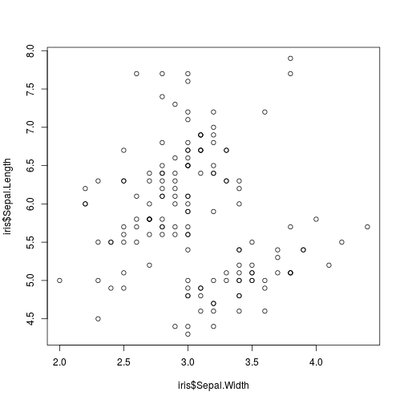

```r
plot(iris$Sepal.Length~iris$Sepal.Width)
```

### Boxplot

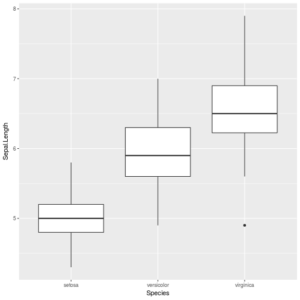

```r
ggplot(data=iris, aes(x = Species, y= Sepal.Length)) +
  geom_boxplot()
```

Compared with base plot:

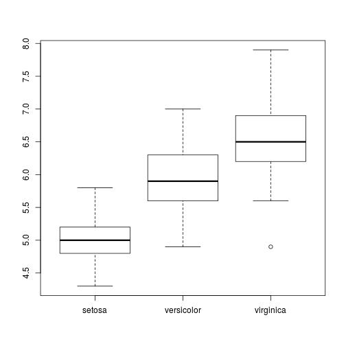

```r
plot(iris$Species,iris$Sepal.Length)
```

### Histogram

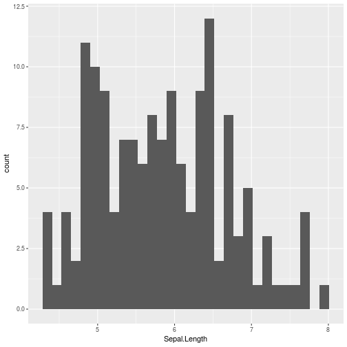

```r
ggplot(data=iris, aes(x = Sepal.Length)) +
  geom_histogram()
```

Compared with base plot:

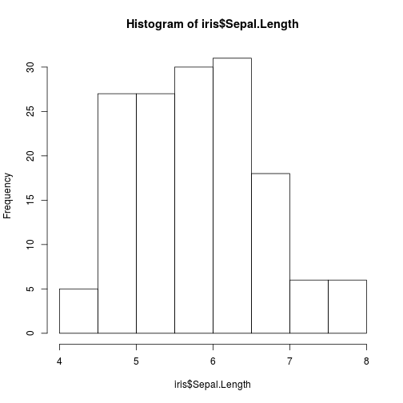

```r
hist(iris$Sepal.Length)
```

### Other possibilities

Adding trendline to scatterplot

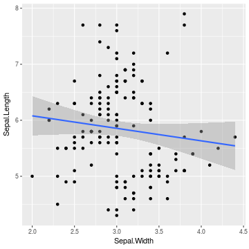

```r
ggplot(data=iris, aes(x = Sepal.Width, y= Sepal.Length)) +
  geom_point() +
  geom_smooth(method='lm')
```

### Lots of other possibilities... I

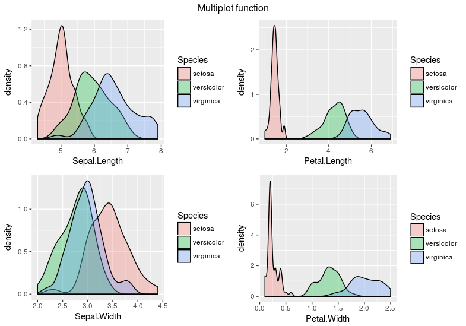

### Lots of other possibilities... II

[figure not shown]

### Lots of other possibilities... III

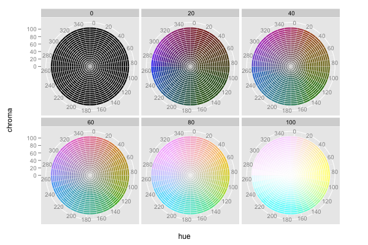

### Lots of other possibilities... IV

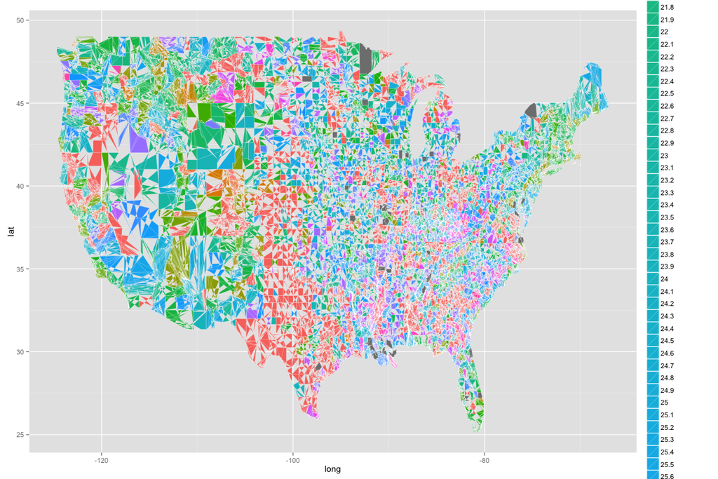

### Advantage over base plot - I

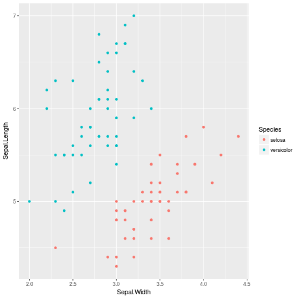

Compared with base plot:

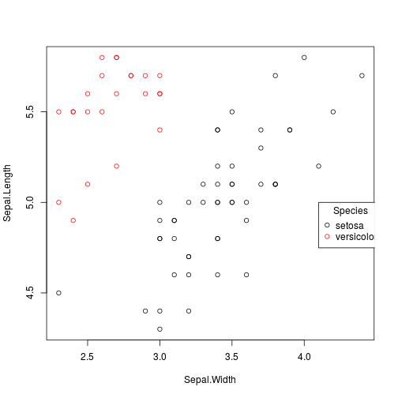

Layout preference debatable…

### Advantage over base plot - II

… length of script not so much.

```r
ggplot(subset(iris, Species %in% c("setosa", "versicolor")),
       aes(x=Sepal.Width,
           y=Sepal.Length,
           color=Species))+
  geom_point()
```

Compared with base plot:

```r
plot(Sepal.Length ~ Sepal.Width,
     data=subset(iris, Species == "setosa"))
points(Sepal.Length ~ Sepal.Width, col = "red",
     data=subset(iris, Species == "versicolor"))
legend(4.1, 5,
       c("setosa", "versicolor"), title="Species",
       col=c("black", "red"),
       pch=c(1, 1))
```

### Not possible

- 3d graphics (rgl package)
- interaction networks (igraph or bipartite package)
- interactive graphs (ggvis package)

### Plot basics - I

**Grammar of graphics**

Building blocks creating graphic displays

- data
- aesthetic mapping
- geometric object
- statistical transformations
- scales
- coordinate system
- position adjustments
- faceting

### Plot basics - II

ggplot()

- calling plot

aes()

- supplying default data
- aesthethic mappings
- add components
- layers
- scales
- coords
- facets

(Skipping statistical layers)

### Plot basics - Data

ggplot calls for data

```r
ggplot(data)
```

Two ways possible

```r
ggplot(data = iris)
```

```r
ggplot(iris)
```

Subsets for data are also possible

```r
ggplot(data = subset(iris, Species %in% c( "sertosa", "versicolor")))
```